# NLS on individual experiments (with `nlsList` from package `nlme`)

Hadrien Chauvin

2020-09-23

```r
library(Prola2020.Sci.Adv)
library(plyr)
library(magrittr)
library(ggplot2)
library(nlme)

df_grouped <- read_experiments()

df_grouped_all <- df_grouped
meta <- ddply(df_grouped_all, c("File"), function (x) {
  data.frame(Population = x$Population[1], Type = x$Type[1])
})
# This comes from a prior NLS fit on all the data together (data not shown)
start <- structure(c(1.79953624594729, 0.0753975243025479, -1.05834556059257,
  0.00875804362445855, -0.243275701393101, 0.0184522361929007), .Names = c("theta1",
    "B1", "theta2", "B2", "theta3", "B3"))

model <- triexpModelFactory(df_grouped_all)
triexp_nlme_model <- formula(model)

st <- proc.time()
triexp.nlsList2 <- nlsList(
  triexp_nlme_model,
  data = df_grouped_all,
  start = start
)
print(proc.time() - st)
```

```
##    user  system elapsed
##  19.534   0.961  21.687
```

```r
# Let's save this
save(triexp.nlsList2, file="../intermediaryData/triexp.nlsList.rda")
```

We can plot intervals

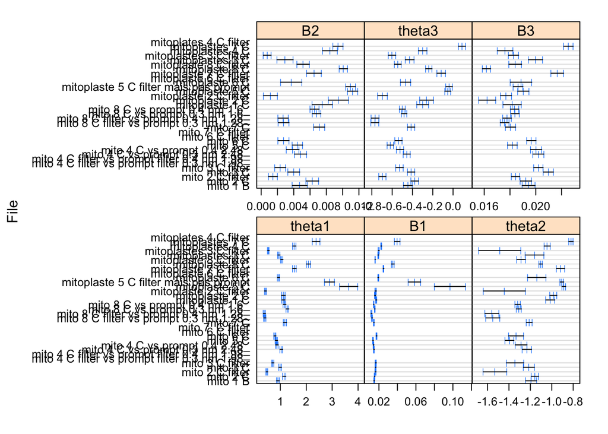

```r
plot(intervals(triexp.nlsList2))
```

You can see that for a number of experiments, convergence did NOT happen:

```r
no_conv <- apply(intervals(triexp.nlsList2), 1, function (x) any(is.na(x)))
print(names(which(no_conv)))
```

```
## [1] "mito 4 C filter vs prompt filter 0.3 nm 1.98_"
## [2] "mito 4 C filter vs prompt filter 0.4 nm 1.98_"
## [3] "mito 6 C filter"
## [4] "mito 7  C filter"
## [5] "mitoplaste 6 C filter"
## [6] "mitoplates 4 C filter"
```

```r
print(sum(no_conv))
```

```
## [1] 6
```

Nota: by using `nlsLM` with weights, this goes a little bit better (see simpleIntervals2.R).

Thetas are not necessarily ordered from low to high (i.e. theta1 lowest), Which is problematic for comparison

```r
thetas_order <- t(apply(
  coef(triexp.nlsList2),
  1,
  function (x) {
    thetas <- x[c("theta1", "theta2", "theta3")]
    setNames(order(thetas), c("low", "mid", "high"))
  }
))
print(thetas_order)
```

```
##                                               low mid high
## mito 1 B                                        2   3    1
## mito 2 C                                        2   3    1
## mito 2 C filter                                 2   3    1
## mito 3 C                                        2   3    1
## mito 3 C filter                                 2   3    1
## mito 4 C filter vs prompt filter 0.3 nm 1.98_   1   2    3
## mito 4 C filter vs prompt filter 0.4 nm 1.98_   1   2    3
## mito 4 C vs prompt 0.3 nm 2.48_                 2   3    1
## mito 4 C vs prompt 0.4 2.48_                    2   3    1
## mito 5 C                                        2   3    1
## mito 6 C                                        2   3    1
## mito 6 C filter                                 1   2    3
## mito 7  C filter                                1   2    3
## mito 7 C                                        2   3    1
## mito 8 C filter vs prompt 0.3 nm 1.28_          2   3    1
## mito 8 C filter vs prompt 0.4 nm 1.28_          2   3    1
## mito 8 C vs prompt 0.3 nm 1.6_                  2   3    1
## mito 8 C vs prompt 0.4 nm 1.6_                  2   3    1
## mitoplaste 1 C                                  2   3    1
## mitoplaste 2 C                                  2   3    1
## mitoplaste 2 C filter                           2   3    1
## mitoplaste 5 C                                  2   3    1
## mitoplaste 5 C filter mais pas prompt           2   3    1
## mitoplaste 6 C                                  2   3    1
## mitoplaste 6 C filter                           1   2    3
## mitoplaste 7 C filter                           2   3    1
## mitoplaste 8 C                                  2   3    1
## mitoplaste 8 C filter                           2   3    1
## mitoplastes 3 C                                 2   3    1
## mitoplastes 3 C filter                          2   3    1
## mitoplastes 4 C                                 2   3    1
## mitoplastes 7 C                                 2   3    1
## mitoplates 4 C filter                           1   2    3
```

We can get a feeling of the result by plotting on a tau/B1 axis To get tau from theta, with confidence intervals, we need to do a transformation with some Monte Carlo sampling

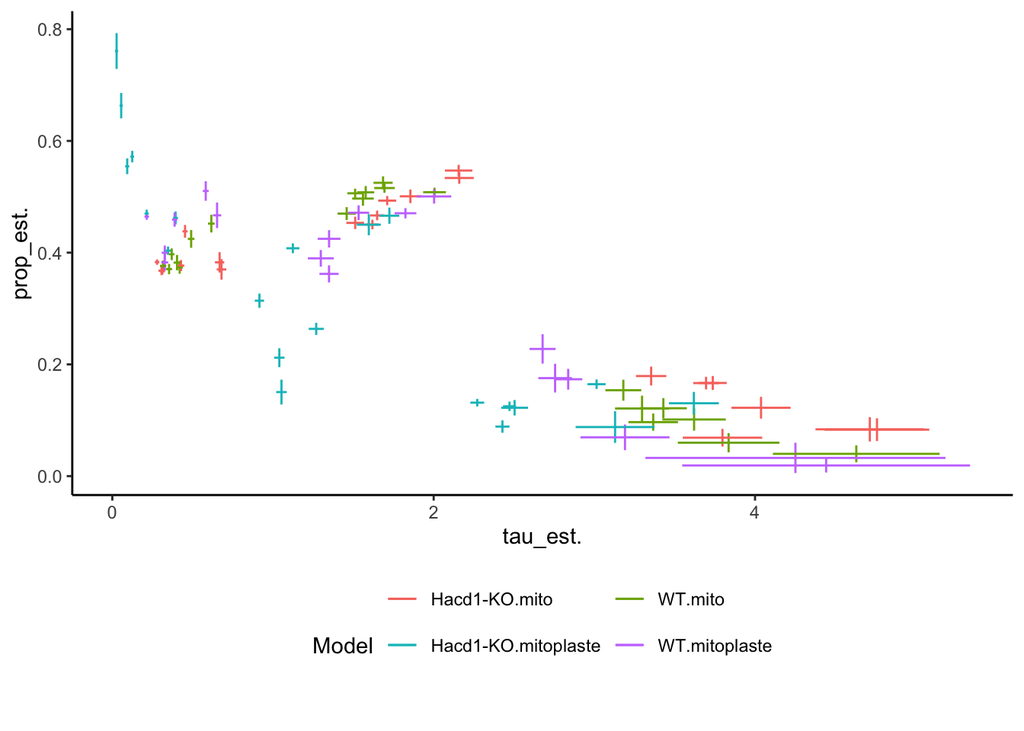

```r
triexp.vcovsMeans <- vcovsMeans(triexp.nlsList2)
df_freq_plot2 <- freqPlotCov(triexp.vcovsMeans)
print(plotFreq(df_freq_plot2))
```

We see that the higher the tau, the more difficult it is to get to a precise pinning of it

Now, let's plot the means and the variances of the means for the interaction of population (WT/Hacd1-KO) and type (mito/mitoplaste). To do this we must re-order the thetas and Bs.

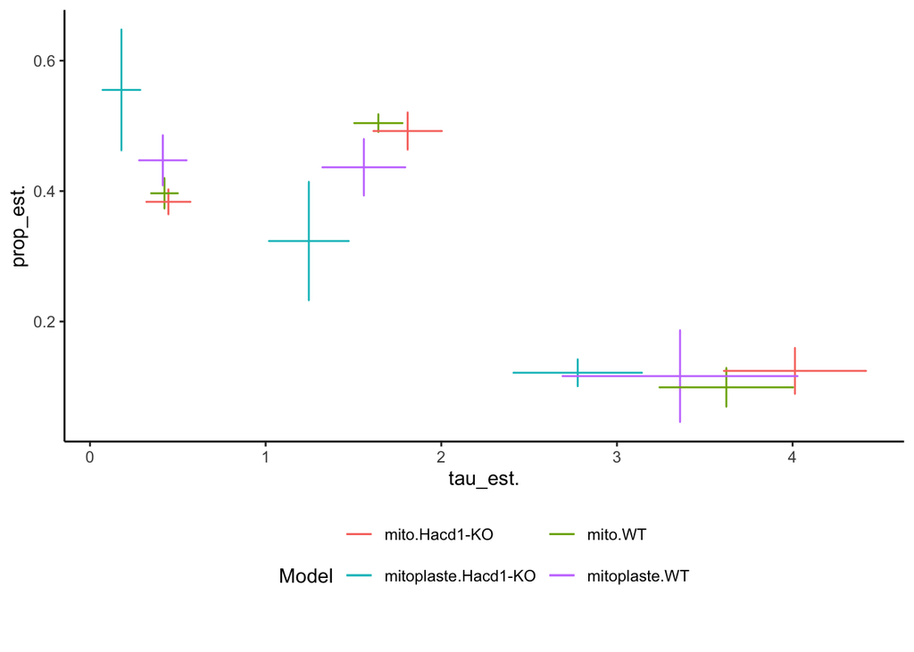

```r
triexp.varsMeans.grouped <- group.varsMeans(meta, triexp.vcovsMeans)

df_freq_plot_grouped <- freqPlotVar(triexp.varsMeans.grouped)
print(plotFreq(df_freq_plot_grouped))
```

In the end, we see a lack of significativity that could be addressed with 1) weighing and Levenberg–Marquardt fitting (simpleIntervals2); 2) mixed effects modelling (groupNlme).